# Distributed Statistical Model Fitting with ADMM Algorithm

Yixuan Qiu & Rongrong Zhang  
2015-12-02

@ STAT 598 Computing for Big Data

### Content

- What is ADMM?
- Distributed Computing with ADMM
- Implementation in Scala/Spark
- Computing on Real Data

## What is ADMM?

### What is ADMM?

- Full name: Alternating Direction Method of Multipliers
- An algorithm for constrained convex optimization problems
- Highlighted features:
  - Provides easy-to-apply solutions to many statistical models
  - Can be easily incorporated into the distributed computing framework
  - A good friend of statistical models

### The Problem

- ADMM is used to solve the following optimization problem:

\[ \begin{aligned} \text{minimize}\quad & f(\theta)+g(z)\\ \text{subject to}\quad & A\theta + Bz = c \end{aligned} \]

- \( \theta \) and \( z \) are vectors to be optimized
- \( A \), \( B \) and \( c \) are known coefficient matrices/vectors
- \( f \) and \( g \) are convex functions
- Looks bizarre? Let's see two familiar examples

### Example — Lasso

\[ \begin{aligned} \min & f(\theta)+g(z)\\ \text{s.t.} & A\theta + Bz = c \end{aligned} \]

- Solve \( \;\min_{\beta}\frac{1}{2n}\Vert y-X\beta\Vert_2^2+\lambda\Vert\beta\Vert_1 \)
- \( f(\beta)=\frac{1}{2n}\Vert y-X\beta\Vert_2^2 \)
- \( g(z)=\lambda\Vert z\Vert_1 \)
- With constraint \( \;\beta-z=0 \)

### How ADMM Works?

\[ \begin{align} \scriptstyle \theta^{k+1} & \scriptstyle :=\underset{\theta}{\arg\min}\left(f(\theta)+\frac{\rho}{2}\Vert A\theta+Bz^{k}-c+u^{k}/\rho\Vert_{2}^{2}\right)\\ \scriptstyle z^{k+1} & \scriptstyle :=\underset{z}{\arg\min}\left(g(z)+\frac{\rho}{2}\Vert A\theta^{k+1}+Bz-c+u^{k}/\rho\Vert_{2}^{2}\right)\\ \scriptstyle u^{k+1} & \scriptstyle :=u^{k}+\rho(A\theta^{k+1}+Bz^{k+1}-c) \end{align} \]

- \( \rho\, \) can be any positive number
- Usually \( \scriptstyle \min_\theta f(\theta)+\frac{\rho}{2}\Vert A\theta+w\Vert_{2}^{2} \) and \( \scriptstyle \min_z g(z)+\frac{\rho}{2}\Vert Bz+w\Vert_{2}^{2} \) are easier to compute than the original problem

### Examples

- Lasso

\[ \begin{align} \scriptstyle \beta^{k+1} & \scriptstyle :=(X'X+\rho I)^{-1}(X'y+\rho z^{k}-u^{k})\\ \scriptstyle z^{k+1} & \scriptstyle :=S_{n\lambda/\rho}(\beta^{k+1}+u^k/\rho)\\ \scriptstyle u^{k+1} & \scriptstyle :=u^{k}+\rho(\beta^{k+1}-z^{k+1}) \end{align} \]

- Median Regression

\[ \begin{align} \scriptstyle \beta^{k+1} & \scriptstyle :=(X'X)^{-1}X'(y+z^{k}-u^{k}/\rho)\\ \scriptstyle z^{k+1} & \scriptstyle :=S_{1/\rho}(X\beta^{k+1}-y+u^{k}/\rho)\\ \scriptstyle u^{k+1} & \scriptstyle :=u^{k}+\rho(X\beta^{k+1}-z^{k+1}-y) \end{align} \]

- where \( \scriptstyle S_{\kappa}(a)=\max(0,1-\kappa/|a|)\cdot a \)

## How to Parallelize?

### Statistical Models

- Usually statistical models have the following form: \[ \min \sum_{i=1}^N f_i(\theta)+g(\theta) \]
- Here \( \,f_i(\theta) \) are partitions of the neg-log-likelihood function: If sample is cut into \( N \) partitions, the log-likelihood can be written as the summation of \( N \) parts
- \( g(\theta) \) can be some penalty terms or prior information
- Models of this form can be easily parallelized

### Parallelized ADMM

- The previous model can be rewritten as

\[ \begin{aligned} \min & \sum_{i=1}^N f_i(\theta_i)+g(z)\\ \text{s.t.} & \theta_i - z = 0,\ i=1,\ldots,N \end{aligned} \]

- The iteration steps are

\[ \begin{align} \scriptstyle \theta_i^{k+1} & \scriptstyle :=\underset{\theta_i}{\arg\min}\left(f_i(\theta_i)+\frac{\rho}{2}\Vert \theta_i-z^{k}+u_i^{k}/\rho\Vert_{2}^{2}\right)\\ \scriptstyle z^{k+1} & \scriptstyle :=\underset{z}{\arg\min}\left(g(z)+\frac{N\rho}{2}\Vert z-\bar{\theta}^{k+1}-\bar{u}^{k}/\rho\Vert_{2}^{2}\right)\\ \scriptstyle u_i^{k+1} & \scriptstyle :=u_i^{k}+\rho(\theta_i^{k+1}-z^{k+1}) \end{align} \]

### Parallelized ADMM

- A diagram of P-ADMM

[figure not shown]

## Implementation in Scala/Spark

### ADMM-Spark

- https://github.com/yixuan/ADMM-Spark
- Currently used to solve logistic lasso regression
- Can be easily extended to general penalized likelihood model \[ \min_{\theta}\, l(\theta)+\lambda\Vert\theta\Vert_1 \]

### Structure

[figure not shown]

### Derived class

- `class PLogisticLasso extends PADMML1`
- Solves sparse logistic regression
- Only needs to implement the function for \( \theta \)-step
- Calls the solver of logistic ridge regression

### Solver class

- `class LogisticRidge`
- `class LogisticRidgeNative`
- Solves the problem \[ \scriptstyle\min_{\theta}\, l(\theta)+\lambda\Vert\theta-v\Vert_2^2 \]
- `LogisticRidge`: pure Java code
- `LogisticRidgeNative`: using C++ code to speed up

### Example Usage

```scala
import statr.stat598bd.PLogisticLasso

// Create RDD objects x and y representing
// the data matrix and response vector
// ...

val model = new PLogisticLasso(x, y, sc)
model.set_lambda(2.0)
model.set_opts(max_iter = 500,
               eps_abs = 1e-3,
               eps_rel = 1e-3,
               logs = true)
model.run()

val beta = model.coef
```

## Real Data Computing

### Tradeshift Data

- Obtained from the Kaggle competition (https://www.kaggle.com/c/tradeshift-text-classification)
- Consists of thousands of documents, in which words are detected and combined to form text blocks

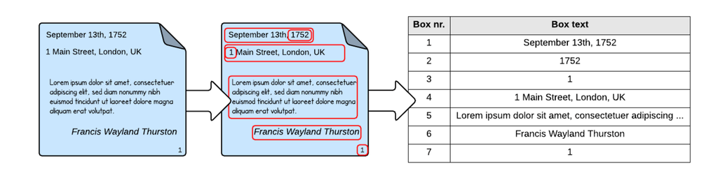

- 1.7 million rows (text blocks) / 145 variables

### Text Classification

- Classify each text block to one or more labels (33 in total), such as date, invoice number or monetary amount

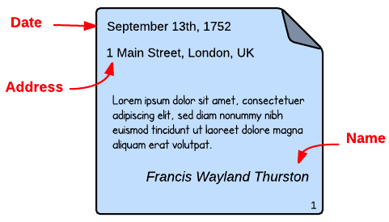

- We consider the 33rd label

### Features

- Numbers: Continuous/discrete numerical values
- Boolean: The values include YES (true) or NO (false)
- Encrypted text

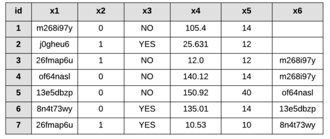

### Overall Flow

- Preprocess the data by removing text and missing values, and encoding YES/NO values to 1/0
- Store the cleaned data to HDFS
- Read data from Spark and randomly split into training set (99%) and tuning set (1%)
- Standardize the training set
- Consider 10 \( \lambda \) values ranging from \( 0.001n \) to \( 0.1n \), equally spaced in the log scale

### Overall Flow - Cont.

- Fit a logistic lasso regression for each \( \lambda \), and calculate the log-likelihood on tuning set
- Select the “optimal” \( \lambda \)
- Obtain the final regression coefficient based on the selected \( \lambda \)

### Timings

- With 10 / 20 Executors
- Cleaning data: 41.3 s / 41.3 s
- Reading data in Spark: 23.6 s / 17.6 s
- Data standardization: 7.9 s / 7.7 s
- Setting up model: 9.4 s / 6.6 s
- Model fitting:

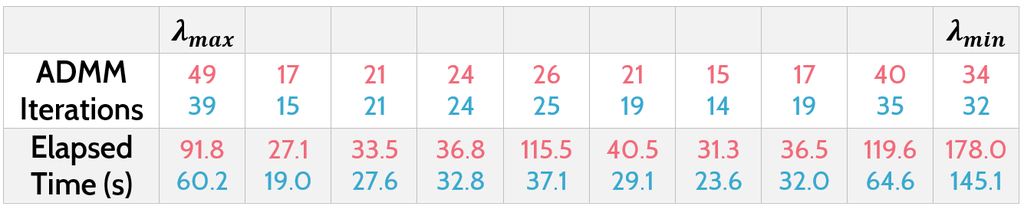

### Timings

- Coding time: FOREVER

“Multithreading: Theory and Practice”

[figure not shown]

(Image from http://wrathematics.github.io/RparallelGuide/)

### References

- Boyd, S., Parikh, N., Chu, E., Peleato, B., & Eckstein, J. (2011). Distributed optimization and statistical learning via the alternating direction method of multipliers. Foundations and Trends® in Machine Learning, 3(1), 1-122.
- Minka, T. P. (2003). Algorithms for maximum-likelihood logistic regression.
- [Spark documentation](http://spark.apache.org/docs/latest/)
- [Breeze documentation](https://github.com/scalanlp/breeze/wiki)
- [Java Native Interface (JNI)](https://www3.ntu.edu.sg/home/ehchua/programming/java/JavaNativeInterface.html)